# Preliminaries

The purpose of this part of the project is to explore the dataset with vehicle sales data. I will make sure the data are in good condition, address any problems I find in the dataset, explore the data with plots, and investigate some pertinent relationships among the variables.

```python
# Load libraries

import pandas as pd
from matplotlib import pyplot as plt
import numpy as np
```

```python
# Load data (with dates parsed)

df_cars = pd.read_csv('../vehicles_us.csv', parse_dates=['date_posted'])
```

# Examine Data

```python
# Examine the df_cars dataframe

display(df_cars.info())
df_cars
```

```
<class 'pandas.core.frame.DataFrame'>
RangeIndex: 51525 entries, 0 to 51524
Data columns (total 13 columns):
 #   Column        Non-Null Count  Dtype
---  ------        --------------  -----
 0   price         51525 non-null  int64
 1   model_year    47906 non-null  float64
 2   model         51525 non-null  object
 3   condition     51525 non-null  object
 4   cylinders     46265 non-null  float64
 5   fuel          51525 non-null  object
 6   odometer      43633 non-null  float64
 7   transmission  51525 non-null  object
 8   type          51525 non-null  object
 9   paint_color   42258 non-null  object
 10  is_4wd        25572 non-null  float64
 11  date_posted   51525 non-null  datetime64[ns]
 12  days_listed   51525 non-null  int64
dtypes: datetime64[ns](1), float64(4), int64(2), object(6)
memory usage: 5.1+ MB
```

```
None
```

|  | price | model_year | model | condition | cylinders | fuel | odometer | transmission | type | paint_color | is_4wd | date_posted | days_listed |
| --- | --- | --- | --- | --- | --- | --- | --- | --- | --- | --- | --- | --- | --- |
| 0 | 9400 | 2011.0 | bmw x5 | good | 6.0 | gas | 145000.0 | automatic | SUV | NaN | 1.0 | 2018-06-23 | 19 |
| 1 | 25500 | NaN | ford f-150 | good | 6.0 | gas | 88705.0 | automatic | pickup | white | 1.0 | 2018-10-19 | 50 |
| 2 | 5500 | 2013.0 | hyundai sonata | like new | 4.0 | gas | 110000.0 | automatic | sedan | red | NaN | 2019-02-07 | 79 |
| 3 | 1500 | 2003.0 | ford f-150 | fair | 8.0 | gas | NaN | automatic | pickup | NaN | NaN | 2019-03-22 | 9 |
| 4 | 14900 | 2017.0 | chrysler 200 | excellent | 4.0 | gas | 80903.0 | automatic | sedan | black | NaN | 2019-04-02 | 28 |
| ... | ... | ... | ... | ... | ... | ... | ... | ... | ... | ... | ... | ... | ... |
| 51520 | 9249 | 2013.0 | nissan maxima | like new | 6.0 | gas | 88136.0 | automatic | sedan | black | NaN | 2018-10-03 | 37 |
| 51521 | 2700 | 2002.0 | honda civic | salvage | 4.0 | gas | 181500.0 | automatic | sedan | white | NaN | 2018-11-14 | 22 |
| 51522 | 3950 | 2009.0 | hyundai sonata | excellent | 4.0 | gas | 128000.0 | automatic | sedan | blue | NaN | 2018-11-15 | 32 |
| 51523 | 7455 | 2013.0 | toyota corolla | good | 4.0 | gas | 139573.0 | automatic | sedan | black | NaN | 2018-07-02 | 71 |
| 51524 | 6300 | 2014.0 | nissan altima | good | 4.0 | gas | NaN | automatic | sedan | NaN | NaN | 2018-06-05 | 10 |

51525 rows × 13 columns

```python
# Examine the price column

display(df_cars['price'].describe())
print()
display(df_cars['price'].value_counts())
```

```
count     51525.000000
mean      12132.464920
std       10040.803015
min           1.000000
25%        5000.000000
50%        9000.000000
75%       16839.000000
max      375000.000000
Name: price, dtype: float64
```

```
price
1        798
6995     719
5995     655
4995     624
3500     620
        ...
58500      1
3993       1
32987      1
3744       1
7455       1
Name: count, Length: 3443, dtype: int64
```

```python
# Examine the model_year column

display(df_cars['model_year'].describe())
print()
display(df_cars['model_year'].value_counts())
```

```
count    47906.000000
mean      2009.750470
std          6.282065
min       1908.000000
25%       2006.000000
50%       2011.000000
75%       2014.000000
max       2019.000000
Name: model_year, dtype: float64
```

```
model_year
2013.0    3549
2012.0    3468
2014.0    3448
2011.0    3375
2015.0    3323
          ...
1948.0       1
1961.0       1
1936.0       1
1949.0       1
1929.0       1
Name: count, Length: 68, dtype: int64
```

```python
# Examine the model column

display(df_cars['model'].describe())
print()
display(df_cars['model'].value_counts())
```

```
count          51525
unique           100
top       ford f-150
freq            2796
Name: model, dtype: object
```

```
model
ford f-150                           2796
chevrolet silverado 1500             2171
ram 1500                             1750
chevrolet silverado                  1271
jeep wrangler                        1119
                                     ...
ford f-250 super duty                 241
acura tl                              236
kia sorento                           236
nissan murano                         235
mercedes-benz benze sprinter 2500      41
Name: count, Length: 100, dtype: int64
```

```python
# Examine the condition column

display(df_cars['condition'].describe())
print()
display(df_cars['condition'].value_counts())
```

```
count         51525
unique            6
top       excellent
freq          24773
Name: condition, dtype: object
```

```
condition
excellent    24773
good         20145
like new      4742
fair          1607
new            143
salvage        115
Name: count, dtype: int64
```

```python
# Examine the cylinders column

display(df_cars['cylinders'].describe())
print()
display(df_cars['cylinders'].value_counts())
```

```
count    46265.000000
mean         6.125235
std          1.660360
min          3.000000
25%          4.000000
50%          6.000000
75%          8.000000
max         12.000000
Name: cylinders, dtype: float64
```

```
cylinders
8.0     15844
6.0     15700
4.0     13864
10.0      549
5.0       272
3.0        34
12.0        2
Name: count, dtype: int64
```

```python
# Examine the fuel column

display(df_cars['fuel'].describe())
print()
display(df_cars['fuel'].value_counts())
```

```
count     51525
unique        5
top         gas
freq      47288
Name: fuel, dtype: object
```

```
fuel
gas         47288
diesel       3714
hybrid        409
other         108
electric        6
Name: count, dtype: int64
```

```python
# Examine the odometer column

display(df_cars['odometer'].describe())
print()
display(df_cars['odometer'].value_counts())
```

```
count     43633.000000
mean     115553.461738
std       65094.611341
min           0.000000
25%       70000.000000
50%      113000.000000
75%      155000.000000
max      990000.000000
Name: odometer, dtype: float64
```

```
odometer
0.0         185
140000.0    183
120000.0    179
130000.0    178
160000.0    167
           ...
138580.0      1
94624.0       1
123321.0      1
202627.0      1
139573.0      1
Name: count, Length: 17762, dtype: int64
```

```python
# Examine the transmission column

display(df_cars['transmission'].describe())
print()
display(df_cars['transmission'].value_counts())
```

```
count         51525
unique            3
top       automatic
freq          46902
Name: transmission, dtype: object
```

```
transmission
automatic    46902
manual        2829
other         1794
Name: count, dtype: int64
```

```python
# Examine the type column

display(df_cars['type'].describe())
print()
display(df_cars['type'].value_counts())
```

```
count     51525
unique       13
top         SUV
freq      12405
Name: type, dtype: object
```

```
type
SUV            12405
truck          12353
sedan          12154
pickup          6988
coupe           2303
wagon           1541
mini-van        1161
hatchback       1047
van              633
convertible      446
other            256
offroad          214
bus               24
Name: count, dtype: int64
```

```python
# Examine the paint_color column

display(df_cars['paint_color'].describe())
print()
display(df_cars['paint_color'].value_counts())
```

```
count     42258
unique       12
top       white
freq      10029
Name: paint_color, dtype: object
```

```
paint_color
white     10029
black      7692
silver     6244
grey       5037
blue       4475
red        4421
green      1396
brown      1223
custom     1153
yellow      255
orange      231
purple      102
Name: count, dtype: int64
```

```python
# Examine the is_4wd column

display(df_cars['is_4wd'].describe())
print()
display(df_cars['is_4wd'].value_counts())
```

```
count    25572.0
mean         1.0
std          0.0
min          1.0
25%          1.0
50%          1.0
75%          1.0
max          1.0
Name: is_4wd, dtype: float64
```

```
is_4wd
1.0    25572
Name: count, dtype: int64
```

```python
# Examine the date_posted column

display(df_cars['date_posted'].describe())
print()
display(df_cars['date_posted'].value_counts())
```

```
count                            51525
mean     2018-10-25 01:57:46.270742528
min                2018-05-01 00:00:00
25%                2018-07-29 00:00:00
50%                2018-10-25 00:00:00
75%                2019-01-21 00:00:00
max                2019-04-19 00:00:00
Name: date_posted, dtype: object
```

```
date_posted
2019-03-17    186
2019-01-05    184
2018-09-20    178
2019-03-11    176
2018-10-09    174
             ...
2018-06-18    119
2018-07-04    118
2019-01-11    117
2018-06-08    117
2019-01-04    116
Name: count, Length: 354, dtype: int64
```

```python
# Examine the days_listed column

display(df_cars['days_listed'].describe())
print()
display(df_cars['days_listed'].value_counts())
```

```
count    51525.00000
mean        39.55476
std         28.20427
min          0.00000
25%         19.00000
50%         33.00000
75%         53.00000
max        271.00000
Name: days_listed, dtype: float64
```

```
days_listed
18     959
24     950
22     945
19     941
20     934
      ...
240      1
209      1
188      1
192      1
186      1
Name: count, Length: 227, dtype: int64
```

```python
# Print out the number of missing values in each column

display(df_cars.info())

df_missing_values = df_cars.isna().sum().reset_index()
df_missing_values.columns = ['column', 'missing values']
display(df_missing_values)
```

```
<class 'pandas.core.frame.DataFrame'>
RangeIndex: 51525 entries, 0 to 51524
Data columns (total 13 columns):
 #   Column        Non-Null Count  Dtype
---  ------        --------------  -----
 0   price         51525 non-null  int64
 1   model_year    47906 non-null  float64
 2   model         51525 non-null  object
 3   condition     51525 non-null  object
 4   cylinders     46265 non-null  float64
 5   fuel          51525 non-null  object
 6   odometer      43633 non-null  float64
 7   transmission  51525 non-null  object
 8   type          51525 non-null  object
 9   paint_color   42258 non-null  object
 10  is_4wd        25572 non-null  float64
 11  date_posted   51525 non-null  datetime64[ns]
 12  days_listed   51525 non-null  int64
dtypes: datetime64[ns](1), float64(4), int64(2), object(6)
memory usage: 5.1+ MB
```

```
None
```

|  | column | missing values |
| --- | --- | --- |
| 0 | price | 0 |
| 1 | model_year | 3619 |
| 2 | model | 0 |
| 3 | condition | 0 |
| 4 | cylinders | 5260 |
| 5 | fuel | 0 |
| 6 | odometer | 7892 |
| 7 | transmission | 0 |
| 8 | type | 0 |
| 9 | paint_color | 9267 |
| 10 | is_4wd | 25953 |
| 11 | date_posted | 0 |
| 12 | days_listed | 0 |

The data looks good overall, but there are a few formatting issues. All the values appear to be integers, so I will convert float64-type columns to Int64 (which preserves missing values). I also want to make sure all text is lowercase.

There are quite a few missing values in the model_year, cylinders, odometer, paint_color, and is_4wd columns. Since the is_4wd column represents True/False data but only contains 1s, I will change all missing values to 0s. It is possible that missing values are meant to be indeterminate and every vehicle for which we have data has four-wheel drive, but that seems unlikely. The rest of the missing data can remain for now.

I also want to extract the make or manufacturer and model or design from the model column. Make seems like a particularly useful variable because it is meaningful and has relatively few unique values, making it more manageable for analysis than model.

# Fix Data

```python
# Check before converting float columns to int

def check_float_for_int(df, column):
    mask = df[column].notna()
    are_equal = np.array_equal(df[column][mask], df[column].astype('Int64')[mask])

    if are_equal:
        print(f"All non-missing values in the {column} column are integers: proceed to convert")
    else:
        print(f"Some non-missing values in the {column} column are not integers: DO NOT convert")

check_float_for_int(df_cars, 'model_year')
check_float_for_int(df_cars, 'cylinders')
check_float_for_int(df_cars, 'odometer')
check_float_for_int(df_cars, 'is_4wd')
```

```
All non-missing values in the model_year column are integers: proceed to convert
All non-missing values in the cylinders column are integers: proceed to convert
All non-missing values in the odometer column are integers: proceed to convert
All non-missing values in the is_4wd column are integers: proceed to convert
```

```python
# Convert float columns to int

df_cars['model_year'] = df_cars['model_year'].astype('Int64')
df_cars['cylinders'] = df_cars['cylinders'].astype('Int64')
df_cars['odometer'] = df_cars['odometer'].astype('Int64')
df_cars['is_4wd'] = df_cars['is_4wd'].astype('Int64')

display(df_cars.info())
df_cars
```

```
<class 'pandas.core.frame.DataFrame'>
RangeIndex: 51525 entries, 0 to 51524
Data columns (total 13 columns):
 #   Column        Non-Null Count  Dtype
---  ------        --------------  -----
 0   price         51525 non-null  int64
 1   model_year    47906 non-null  Int64
 2   model         51525 non-null  object
 3   condition     51525 non-null  object
 4   cylinders     46265 non-null  Int64
 5   fuel          51525 non-null  object
 6   odometer      43633 non-null  Int64
 7   transmission  51525 non-null  object
 8   type          51525 non-null  object
 9   paint_color   42258 non-null  object
 10  is_4wd        25572 non-null  Int64
 11  date_posted   51525 non-null  datetime64[ns]
 12  days_listed   51525 non-null  int64
dtypes: Int64(4), datetime64[ns](1), int64(2), object(6)
memory usage: 5.3+ MB
```

```
None
```

|  | price | model_year | model | condition | cylinders | fuel | odometer | transmission | type | paint_color | is_4wd | date_posted | days_listed |
| --- | --- | --- | --- | --- | --- | --- | --- | --- | --- | --- | --- | --- | --- |
| 0 | 9400 | 2011 | bmw x5 | good | 6 | gas | 145000 | automatic | SUV | NaN | 1 | 2018-06-23 | 19 |
| 1 | 25500 | <NA> | ford f-150 | good | 6 | gas | 88705 | automatic | pickup | white | 1 | 2018-10-19 | 50 |
| 2 | 5500 | 2013 | hyundai sonata | like new | 4 | gas | 110000 | automatic | sedan | red | <NA> | 2019-02-07 | 79 |
| 3 | 1500 | 2003 | ford f-150 | fair | 8 | gas | <NA> | automatic | pickup | NaN | <NA> | 2019-03-22 | 9 |
| 4 | 14900 | 2017 | chrysler 200 | excellent | 4 | gas | 80903 | automatic | sedan | black | <NA> | 2019-04-02 | 28 |
| ... | ... | ... | ... | ... | ... | ... | ... | ... | ... | ... | ... | ... | ... |
| 51520 | 9249 | 2013 | nissan maxima | like new | 6 | gas | 88136 | automatic | sedan | black | <NA> | 2018-10-03 | 37 |
| 51521 | 2700 | 2002 | honda civic | salvage | 4 | gas | 181500 | automatic | sedan | white | <NA> | 2018-11-14 | 22 |
| 51522 | 3950 | 2009 | hyundai sonata | excellent | 4 | gas | 128000 | automatic | sedan | blue | <NA> | 2018-11-15 | 32 |
| 51523 | 7455 | 2013 | toyota corolla | good | 4 | gas | 139573 | automatic | sedan | black | <NA> | 2018-07-02 | 71 |
| 51524 | 6300 | 2014 | nissan altima | good | 4 | gas | <NA> | automatic | sedan | NaN | <NA> | 2018-06-05 | 10 |

51525 rows × 13 columns

```python
# Check if strings are all lowercase

def check_lowercase(df, column):
    if df[column].str.islower().all():
        print(f"All non-missing values in the {column} column are lowercase")
    else:
        print(f"Some non-missing values in the {column} column are NOT lowercase")

check_lowercase(df_cars, 'model')
check_lowercase(df_cars, 'condition')
check_lowercase(df_cars, 'fuel')
check_lowercase(df_cars, 'transmission')
check_lowercase(df_cars, 'type')
check_lowercase(df_cars, 'paint_color')
```

```
All non-missing values in the model column are lowercase
All non-missing values in the condition column are lowercase
All non-missing values in the fuel column are lowercase
All non-missing values in the transmission column are lowercase
Some non-missing values in the type column are NOT lowercase
All non-missing values in the paint_color column are lowercase
```

```python
# Convert type column to lowercase

df_cars['type'] = df_cars['type'].str.lower()

check_lowercase(df_cars, 'type')
```

```
All non-missing values in the type column are lowercase
```

```python
# Convert missing values to 0s for the is_4wd column

df_cars['is_4wd'] = df_cars['is_4wd'].fillna(0)

# Check to see if new values make sense

display(df_cars['is_4wd'].value_counts())
print()
display(df_cars.groupby('model')['is_4wd'].mean().sort_values(ascending=False).head(10))
print()
df_cars.groupby('model')['is_4wd'].mean().sort_values(ascending=False).tail(10)
```

```
is_4wd
0    25953
1    25572
Name: count, dtype: Int64
```

```
model
chevrolet silverado 1500 crew    0.993399
jeep wrangler unlimited          0.982301
subaru forester                  0.977273
jeep wrangler                    0.974084
subaru outback                    0.97026
ford f150 supercrew cab xlt      0.966361
subaru impreza                      0.956
gmc sierra 2500hd                0.942922
bmw x5                           0.910112
ford f-250 super duty            0.879668
Name: is_4wd, dtype: Float64
```

```
model
chevrolet malibu                     0.003241
kia soul                             0.002865
hyundai elantra                      0.002364
nissan sentra                        0.002012
ford econoline                            0.0
ford mustang gt coupe 2d                  0.0
mercedes-benz benze sprinter 2500         0.0
toyota prius                              0.0
chevrolet impala                          0.0
chevrolet camaro lt coupe 2d              0.0
Name: is_4wd, dtype: Float64
```

Whereas vehicles with very high values in the is_4wd column are mostly trucks and SUVs, those with very low values tend to be compact and sports cars, so the new values appear to make sense.

```python
# Extract make and model/design from the model column

df_cars['make'] = df_cars['model'].str.split().str[0]
df_cars['design'] = df_cars['model'].str.split().str[1:].str.join(' ')

df_cars
```

|  | price | model_year | model | condition | cylinders | fuel | odometer | transmission | type | paint_color | is_4wd | date_posted | days_listed | make | design |
| --- | --- | --- | --- | --- | --- | --- | --- | --- | --- | --- | --- | --- | --- | --- | --- |
| 0 | 9400 | 2011 | bmw x5 | good | 6 | gas | 145000 | automatic | suv | NaN | 1 | 2018-06-23 | 19 | bmw | x5 |
| 1 | 25500 | <NA> | ford f-150 | good | 6 | gas | 88705 | automatic | pickup | white | 1 | 2018-10-19 | 50 | ford | f-150 |
| 2 | 5500 | 2013 | hyundai sonata | like new | 4 | gas | 110000 | automatic | sedan | red | 0 | 2019-02-07 | 79 | hyundai | sonata |
| 3 | 1500 | 2003 | ford f-150 | fair | 8 | gas | <NA> | automatic | pickup | NaN | 0 | 2019-03-22 | 9 | ford | f-150 |
| 4 | 14900 | 2017 | chrysler 200 | excellent | 4 | gas | 80903 | automatic | sedan | black | 0 | 2019-04-02 | 28 | chrysler | 200 |
| ... | ... | ... | ... | ... | ... | ... | ... | ... | ... | ... | ... | ... | ... | ... | ... |
| 51520 | 9249 | 2013 | nissan maxima | like new | 6 | gas | 88136 | automatic | sedan | black | 0 | 2018-10-03 | 37 | nissan | maxima |
| 51521 | 2700 | 2002 | honda civic | salvage | 4 | gas | 181500 | automatic | sedan | white | 0 | 2018-11-14 | 22 | honda | civic |
| 51522 | 3950 | 2009 | hyundai sonata | excellent | 4 | gas | 128000 | automatic | sedan | blue | 0 | 2018-11-15 | 32 | hyundai | sonata |
| 51523 | 7455 | 2013 | toyota corolla | good | 4 | gas | 139573 | automatic | sedan | black | 0 | 2018-07-02 | 71 | toyota | corolla |
| 51524 | 6300 | 2014 | nissan altima | good | 4 | gas | <NA> | automatic | sedan | NaN | 0 | 2018-06-05 | 10 | nissan | altima |

51525 rows × 15 columns

# Expore and Plot Data

```python
# Create a function to plot histograms

def histogram(df, column, label, bins=25, angle=0, cutoff=0, cutoff_value=0):
    display(df[column].describe())

    if cutoff:
        if cutoff == '<':
            plt.hist(df[df[column] <= cutoff_value][column], bins=bins)
        elif cutoff == '>':
            plt.hist(df[df[column] >= cutoff_value][column], bins=bins)
        else:
            print("Enter a cutoff direction")
    else:
        plt.hist(df[column], bins=bins)

    plt.xlabel(label)
    plt.ylabel('Number of Observations')
    plt.title(label)
    plt.xticks(rotation=angle)
    plt.show()
```

```
count     51525.000000
mean      12132.464920
std       10040.803015
min           1.000000
25%        5000.000000
50%        9000.000000
75%       16839.000000
max      375000.000000
Name: price, dtype: float64
```

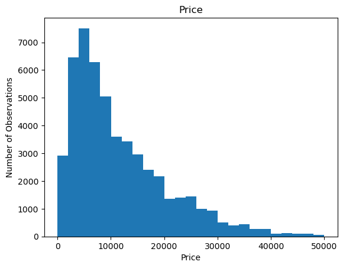

```python
# Examine the distribution of price

histogram(df_cars, 'price', 'Price', cutoff='<', cutoff_value=50000)
```

```
count          43633.0
mean     115553.461738
std       65094.611341
min                0.0
25%            70000.0
50%           113000.0
75%           155000.0
max           990000.0
Name: odometer, dtype: Float64
```

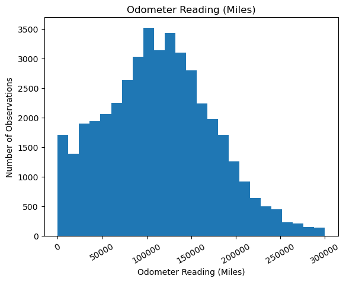

```python
# Examine the distribution of odometer

histogram(df_cars, 'odometer', 'Odometer Reading (Miles)', angle=30, cutoff='<', cutoff_value=300000)
```

```
count       47906.0
mean     2009.75047
std        6.282065
min          1908.0
25%          2006.0
50%          2011.0
75%          2014.0
max          2019.0
Name: model_year, dtype: Float64
```

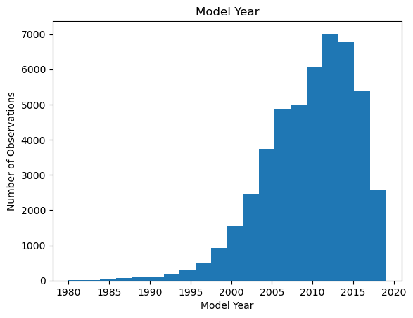

```python
# Examine the distribution of model_year

histogram(df_cars, 'model_year', 'Model Year', bins=20, cutoff='>', cutoff_value=1980)
```

```
count    51525.00000
mean        39.55476
std         28.20427
min          0.00000
25%         19.00000
50%         33.00000
75%         53.00000
max        271.00000
Name: days_listed, dtype: float64
```

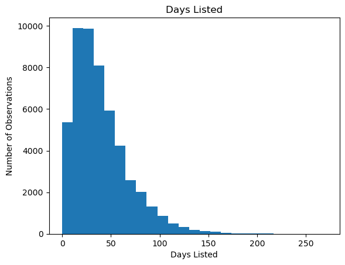

```python
# Examine the distribution of days listed

histogram(df_cars, 'days_listed', 'Days Listed')
```

```python
# Create a function to plot bar charts of category counts

def bar_chart_count(df, column, label, angle=0):
    df_grouped = pd.DataFrame(df.groupby([column])[column].agg(['count'])).sort_values(by='count', ascending=False).reset_index()
    display(df_grouped)

    plt.bar(df_grouped[column], df_grouped['count'])
    plt.xlabel(label)
    plt.ylabel('Quantity')
    plt.title(f'Quantity by {label}')
    plt.xticks(rotation=angle)
    plt.show()
```

|  | make | count |
| --- | --- | --- |
| 0 | ford | 12672 |
| 1 | chevrolet | 10611 |
| 2 | toyota | 5445 |
| 3 | honda | 3485 |
| 4 | ram | 3316 |
| 5 | jeep | 3281 |
| 6 | nissan | 3208 |
| 7 | gmc | 2378 |
| 8 | subaru | 1272 |
| 9 | dodge | 1255 |
| 10 | hyundai | 1173 |
| 11 | volkswagen | 869 |
| 12 | chrysler | 838 |
| 13 | kia | 585 |
| 14 | cadillac | 322 |
| 15 | buick | 271 |
| 16 | bmw | 267 |
| 17 | acura | 236 |
| 18 | mercedes-benz | 41 |

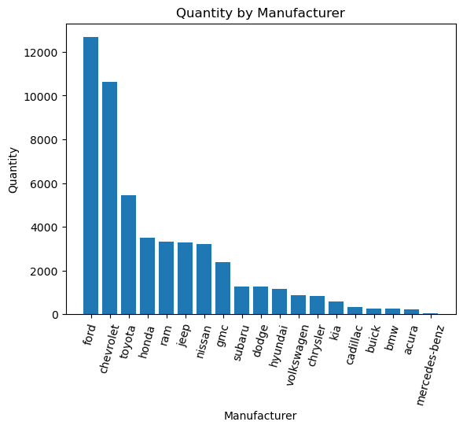

```python
# Plot a bar chart for make

bar_chart_count(df_cars, 'make', 'Manufacturer', 75)
```

|  | condition | count |
| --- | --- | --- |
| 0 | excellent | 24773 |
| 1 | good | 20145 |
| 2 | like new | 4742 |
| 3 | fair | 1607 |
| 4 | new | 143 |
| 5 | salvage | 115 |

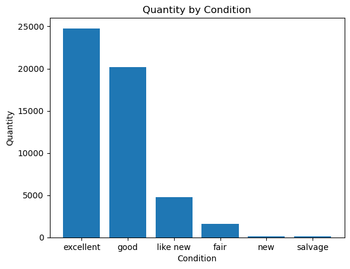

```python
# Plot a bar chart for condition

bar_chart_count(df_cars, 'condition', 'Condition')
```

|  | cylinders | count |
| --- | --- | --- |
| 0 | 8 | 15844 |
| 1 | 6 | 15700 |
| 2 | 4 | 13864 |
| 3 | 10 | 549 |
| 4 | 5 | 272 |
| 5 | 3 | 34 |
| 6 | 12 | 2 |

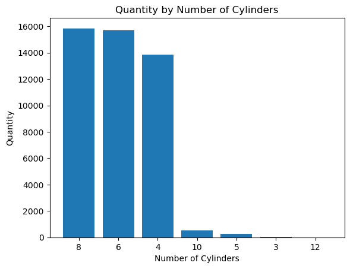

```python
# Plot a bar chart for cylinders

bar_chart_count(df_cars['cylinders'].dropna().astype(str).reset_index(), 'cylinders', 'Number of Cylinders')
```

|  | fuel | count |
| --- | --- | --- |
| 0 | gas | 47288 |
| 1 | diesel | 3714 |
| 2 | hybrid | 409 |
| 3 | other | 108 |
| 4 | electric | 6 |

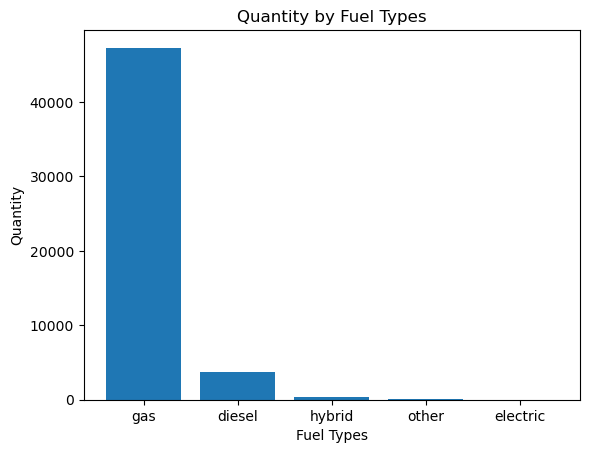

```python
# Plot a bar chart for fuel

bar_chart_count(df_cars, 'fuel', 'Fuel Types')
#Fuel types is worthless
```

|  | transmission | count |
| --- | --- | --- |
| 0 | automatic | 46902 |
| 1 | manual | 2829 |
| 2 | other | 1794 |

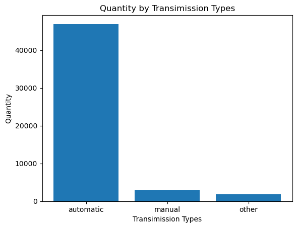

```python
# Plot a bar chart for transmission

bar_chart_count(df_cars, 'transmission', 'Transimission Types')
# Transmission is worthless
```

|  | type | count |
| --- | --- | --- |
| 0 | suv | 12405 |
| 1 | truck | 12353 |
| 2 | sedan | 12154 |
| 3 | pickup | 6988 |
| 4 | coupe | 2303 |
| 5 | wagon | 1541 |
| 6 | mini-van | 1161 |
| 7 | hatchback | 1047 |
| 8 | van | 633 |
| 9 | convertible | 446 |
| 10 | other | 256 |
| 11 | offroad | 214 |
| 12 | bus | 24 |

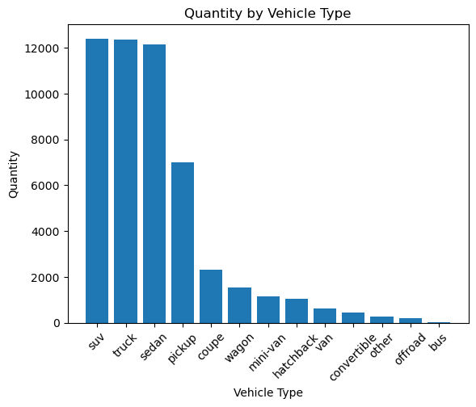

```python
# Plot a bar chart for type

bar_chart_count(df_cars, 'type', 'Vehicle Type', 45)
```

|  | paint_color | count |
| --- | --- | --- |
| 0 | white | 10029 |
| 1 | black | 7692 |
| 2 | silver | 6244 |
| 3 | grey | 5037 |
| 4 | blue | 4475 |
| 5 | red | 4421 |
| 6 | green | 1396 |
| 7 | brown | 1223 |
| 8 | custom | 1153 |
| 9 | yellow | 255 |
| 10 | orange | 231 |
| 11 | purple | 102 |

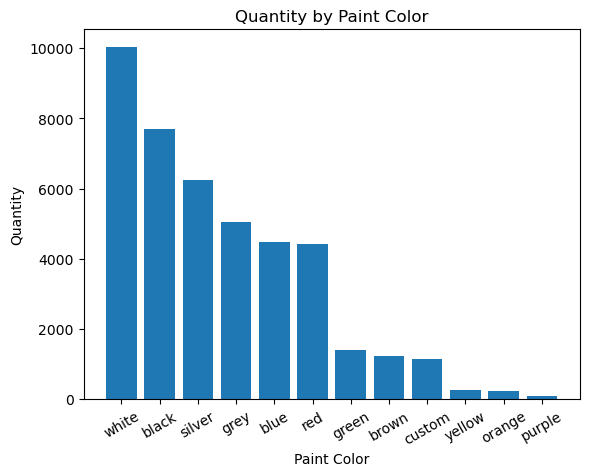

```python
# Plot a bar chart for paint color

bar_chart_count(df_cars, 'paint_color', 'Paint Color', 30)
# paint is interesting but let's not focus on it
```

|  | is_4wd | count |
| --- | --- | --- |
| 0 | 0 | 25953 |
| 1 | 1 | 25572 |

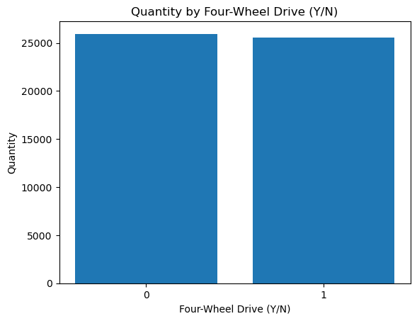

```python
# Plot a bar chart for 4wd

bar_chart_count(df_cars['is_4wd'].dropna().astype(str).reset_index(), 'is_4wd', 'Four-Wheel Drive (Y/N)')
```

With so many variables, numerous analyses are possible. In the absence of any guidance, I will choose a few that strike me as interesting. I plan to focus on price, days listed, and odometer as dependent variables and make, condition, vehicle type, and model year as independent variables.

# Investigate Relationships Among Variables

```python
# Create a function to plot bar charts of variable averages

def bar_chart_avg(df, x_column, y_column, x_label, y_label, angle=0):
    df_clean = df[[x_column, y_column]].dropna()
    df_grouped = df_clean.groupby([x_column])[y_column].agg(['mean']).sort_values(by='mean', ascending=False).reset_index()

    plt.bar(df_grouped[x_column], df_grouped['mean'])
    plt.xlabel(x_label)
    plt.ylabel(f'Average {y_label}')
    plt.title(f'Average {y_label} by {x_label}')
    plt.xticks(rotation=angle)
    plt.show()
```

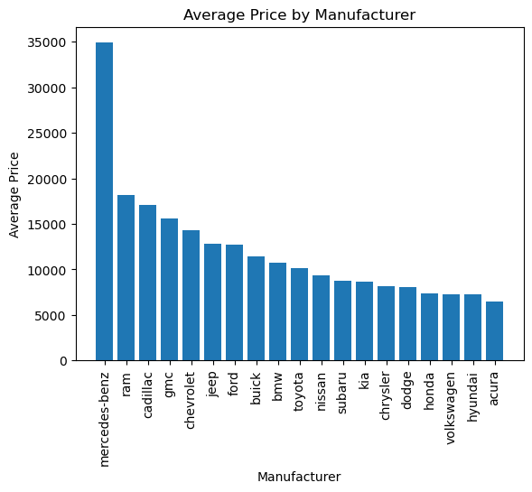

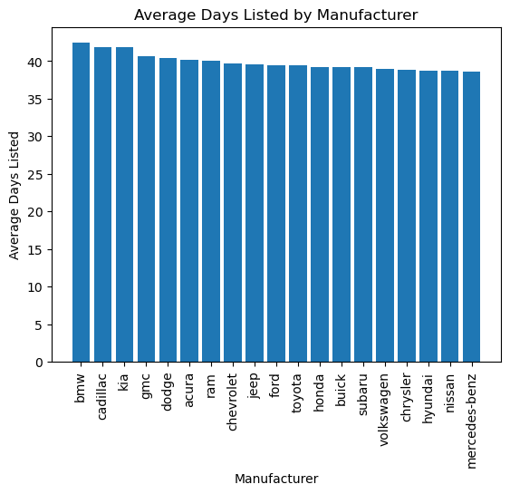

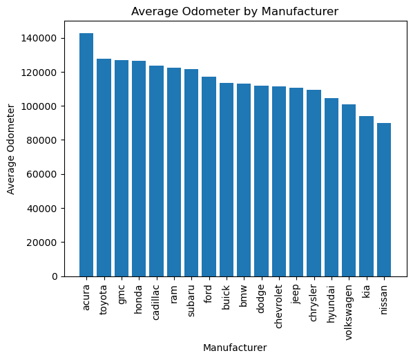

```python
# Plot price, days listed, and odometer by make

bar_chart_avg(df_cars, 'make', 'price', 'Manufacturer', 'Price', 90)
bar_chart_avg(df_cars, 'make', 'days_listed', 'Manufacturer', 'Days Listed', 90)
bar_chart_avg(df_cars, 'make', 'odometer', 'Manufacturer', 'Odometer', 90)
```

Mercedez-Benz sells for much higher average prices than the rest followed by Ram, Cadillac, and GMC with Hyundai and Acura selling for least. BMW, Cadillac, and Kia take the longest to sell, though not by much. Acuras have noticeably more miles on their odometers than the rest followed by Toyota, GMC, and Honda with Kia and Nissan at the bottom.

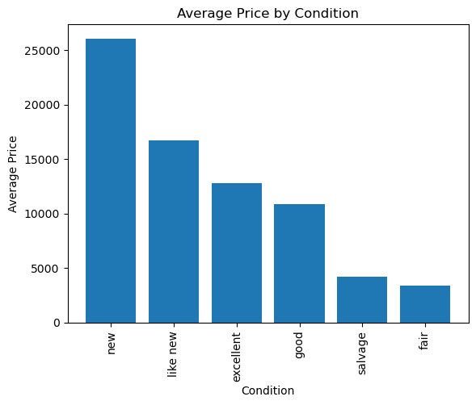

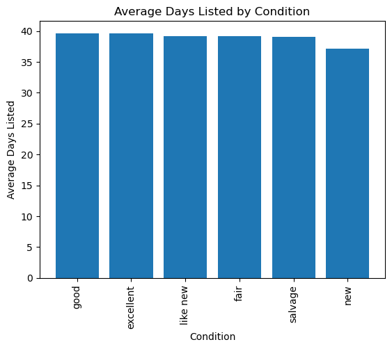

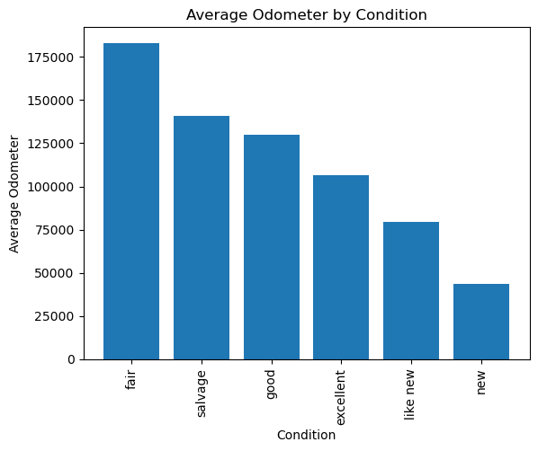

```python
# Plot price, days listed, and odometer by condition

bar_chart_avg(df_cars, 'condition', 'price', 'Condition', 'Price', 90)
bar_chart_avg(df_cars, 'condition', 'days_listed', 'Condition', 'Days Listed', 90)
bar_chart_avg(df_cars, 'condition', 'odometer', 'Condition', 'Odometer', 90)
```

Condition has a very clear effect on prices. New vehicles sell for noticeably more than the rest followed by like new, excellent, and good with salvage and fair noticeably lower. New cars sellslightly faster than the rest, but not by much. Predictably, fair vehicles have noticeably higher odometer readings followed by salvage, good, and excellent with like new and new at the bottom.

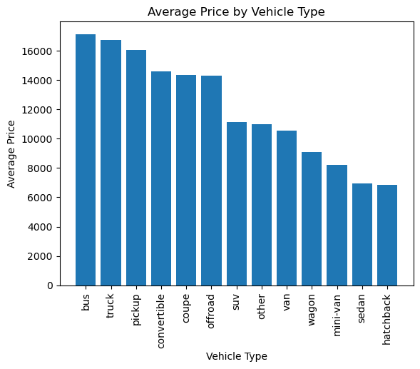

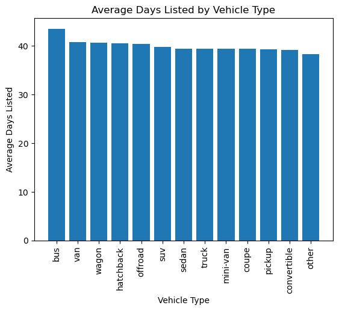

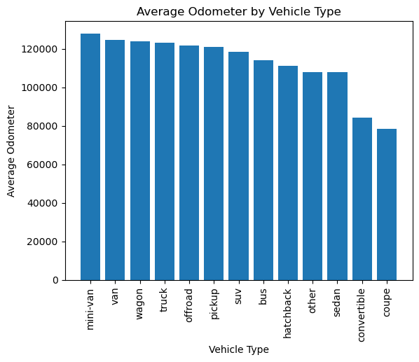

```python
# Plot price, days listed, and odometer by vehicle type

bar_chart_avg(df_cars, 'type', 'price', 'Vehicle Type', 'Price', 90)
bar_chart_avg(df_cars, 'type', 'days_listed', 'Vehicle Type', 'Days Listed', 90)
bar_chart_avg(df_cars, 'type', 'odometer', 'Vehicle Type', 'Odometer', 90)
```

Buses have the highest prices, followed by trucks and pickups with sedans and hatchbacks selling for the least. Buses also take noticeably longer to sell than other vehicles followed by vans and wagons. Mini-vans have the most odometer miles followed by vans, wagons, and trucks with convertibles and coupes coming in considerably lower than the rest.

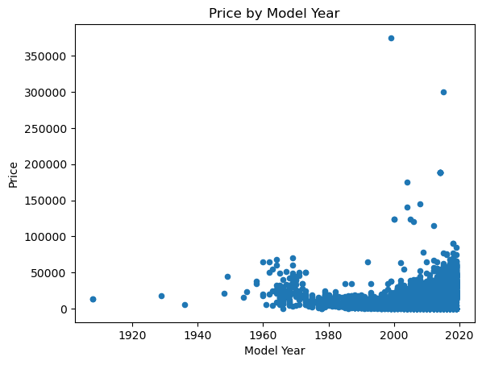

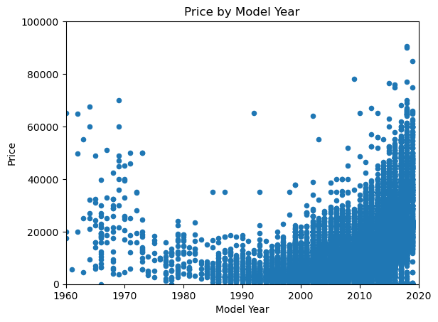

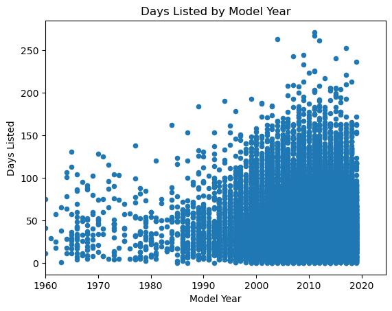

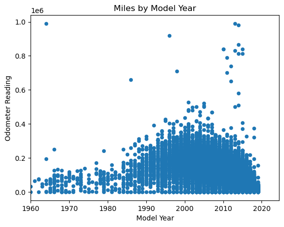

```python
# Plot a scatter chart for price, days listed, and odometer by model year

df_cars.plot(x='model_year', y='price', kind='scatter', xlabel='Model Year', ylabel='Price', title='Price by Model Year')
df_cars.plot(x='model_year', y='price', kind='scatter', xlim=(1960,2020), ylim=(0, 100000), xlabel='Model Year', ylabel='Price', title='Price by Model Year')
df_cars.plot(x='model_year', y='days_listed', kind='scatter', xlim=1960, xlabel='Model Year', ylabel='Days Listed', title='Days Listed by Model Year')
df_cars.plot(x='model_year', y='odometer', kind='scatter', xlim=1960, xlabel='Model Year', ylabel='Odometer Reading', title='Miles by Model Year')
```

Prices are fairly high until around 1975 when they suddenly collapse and gradually climb ever since. They regain pre-1975 prices around 2015 and rise ever higher at a precipitous rate. Occasional very high outlier prices begin just before the year 2000.

Days listed and odometer readings increase steadily between around 1985 and 2005 before reaching a plateau. Odometer readings then decline since 2005 with a spike of very high outliers in the 2010.

# Conclusions

The data reveal a few interesting suggestions for car buyers. If you're looking for an inexpensive car that runs for many miles, Acura is a good manufacturer to consider. Similarly, mini-vans, wagons, and vans appear to be good value vehicle types. New vehicles are reliably the most expensive, but classics can have prices nearly as high. Vehicles since around 1985 can handle more miles and take longer to sell.

Price, odometer, make, type, and model year are all worthwhile variables to investigate. Condition is a boring independent variable because its insights are obvious: new cars cost more and have fewer miles than old cars. Days listed is also less useful than the other dependent variables because it varies little between categories.